# Prácticas de Estadística. Práctica 1

Estadística Descriptiva

Dr. Antonio José Sáez Castillo, Departamento de Estadística e Investigación Operativa, Escuela Politécnica Superior de Linares, Universidad de Jaén

Versi?n 01-diciembre-2020

# Objetivos

El objetivo general de la pr?ctica es familiarizaros con el manejo de las funciones que permiten realizar un an?lisis estad?stico descriptivo b?sico.

M?s concretamente, podemos destacar los siguientes objetivos espec?ficos:

- Aprender a importar datos y el manejo de variables.
- Obtener distribuciones de frecuencias en forma de tablas o representaciones gr?ficas.
- Obtener medidas de posici?n, dispersi?n y forma.
- Identificar valores at?picos.

# Funciones b?sicas

| Funci?n | Acci?n | Sintaxis b?sica |
| --- | --- | --- |
| table() | Distribuci?n de frecuencias absolutas | table(variable) |
| barplot() | Diagrama de barras | barplot(tabla) |
| hist() | Histograma | hist(variable) |
| boxplot() | Diagrama de caja | boxplot(variable) |
| mean() | Media | mean(variable) |
| sd() | Desviaci?n t?pica | sd(variable) |
| quantile() | Cuantiles | quantile(variable, probs = p) |

Ahora vamos a tratar de ilustrar c?mo trabajan estas funciones con el desarrollo de un mini-proyecto. Es importante que te lo tomes *de menos a m?s*, es decir, que al principio te centres en aprender el funcionamiento b?sico, y posteriormente vayas profundizando poco a poco en los detalles de su uso.

# An?lisis de indicadores de consumo dom?stico y de generaci?n de residuos en los municipios de la provincia de Ja?n

## Resumen

El presente documento analiza la tasa de consumo el?ctrico, el consumo de agua y la cantidad de residuos s?lidos urbanos generados por habitante en la provincia de Ja?n en 2008. Se trata de un an?lisis estad?stico de tipo descriptivo que muestra una importante variabilidad en el consumo el?ctrico, probablemente como consecuencia de la inclusi?n del sector industrial en la variable observada. Igualmente, destaca el hallazgo de un patr?n at?pico, bimodal, en la tasa de residuos generados por habitante que podr?a ser objeto de posteriores an?lisis.

## Introducci?n

La provincia de Ja?n comprende un total de 96 municipios de una tipolog?a muy diversa. La capital es la menos pobladas de Andaluc?a y una de las m?s menos pobladas de Espa?a; a?n as?, es la ciudad m?s importante, en cuanto a poblaci?n de la provincia, muy por encima del resto de municipios, la mayor?a de los cuales pertenecen a un ?mbito rural muy vinculado a la explotaci?n del olivar.

El objetivo general de este trabajo es el de analizar tres indicadores de consumo en el hogar para tratar de describir el patr?n de comportamiento de los municipios y, si existen, anomal?as entre ellos. Como objetivos espec?ficos, destacamos:

1. Realizar un an?lisis descriptivo b?sico de los tres indicadores.
2. Identificar la presencia de valores at?picos, tratando de explicar el sentido de la anomal?a.

## M?todos

Los datos han sido descargados desde la herramienta **Sistema de informaci?n multiterritoria** del Instituto de Estad?stica y Cartograf?a de Andaluc?a (IECA). Las variables originalmente descargadas se refieren a todos los municipios de la provincia de Ja?n, y recogen:

1. C?digo INE del municipio
2. Nombre del municipio
3. Consumo total de energ?a el?ctrica del municipio, en Megavatios/Hora.
4. Consumo de agua en invierno del munipipio, en metros c?bicos al d?a.
5. Consumo de agua en verano del municipio, en metros c?bicos al d?a.
6. Destino de los residuos s?lidos urbanos del municipio, con tres valores posibles: planta de compostaje, vertedero controlado y vertedero incontrolado.
7. Cantidad total de residuos s?lidos urbanos generados en el municipio, en toneladas m?tricas.
8. N?mero de habitantes seg?n el padr?n municipal a 31 de diciembre de 2008.

A partir de esas variables hemos obtenido tasas por habitantes de los indicadores deseados. Concretamente:

$$\text{Tasa de consumo de agua} = \frac{\text{Consumo en invierno} + \text{Consumo en verano}}{\text{Habitantes}}$$
$$\text{Tasa de consumo el?ctrico} = \frac{\text{Consumo total}}{\text{Habitantes}}$$

$$\text{Tasa de residuos generados} = \frac{\text{Total de residuos generados}}{\text{Habitantes}}$$

```
## [1] "CodigoINE"                          "Municipio"
## [3] "Consumo.de.energia.electrica"       "Consumo.de.agua..Invierno"
## [5] "Consumo.de.agua..Verano"            "Residuos.solidos.urbanos..Destino"
## [7] "Residuos.solidos.urbanos..Cantidad" "Poblacion"
```

Las variables que se analizan en el trabajo son precisamente estas tres tasas por habitante y el destino de los residuos s?lidos urbanos.

En el caso del destino de los residuos, dado que se trata de una variable cualitativa, se ha obtenido su distribuci?n de frecuencias, que se plasma en un diagrama de barras. Para las tres tasas, al tratarse de variables de tipo cuantitativo continuo, se proporciona:

1. Una representaci?n de su distribuci?n de frecuencias a trav?s de un histograma.
2. Medidas de posici?n (media y cuartiles), dispersi?n (coeficiente de variaci?n) y forma (coeficiente de asimetr?a de Fisher).
3. Una representaci?n en un diagrama de caja para identificar los valores at?picos.

## Resultados

La distribuci?n de frecuencias de la variable sobre el destino de los residuos s?lidos urbanos aparece en la Tabla 1, donde se han incluido tanto las frecuencias absolutas como las relativas, expresadas ?stas en porcentajes. Dicha distribuci?n de frecuencias aparece igualmente representada en el diagrama de barras de la Figura 1.

```
##
##             Compostaje   Vertedero controlado Vertedero incontrolado
##                     24                     61                     11
```

Tabla 1. Distribuci?n de frecuencias del destino de los residuos s?lidos urbanos

| Destino | Frecuencia | Porcentaje |
| --- | --- | --- |
| Compostaje | 24 | 25.00 |
| Vertedero controlado | 61 | 63.54 |
| Vertedero incontrolado | 11 | 11.46 |

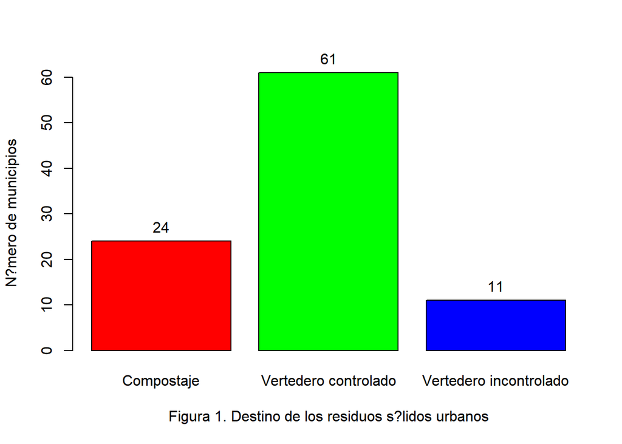

Por su parte, en lo que se refiere a las tasas de consumo de agua, el?ctrico y de generaci?n de residuos por habitante, su distribuci?n de frecuencias aparece representada en los histogramas de la Figura 2.

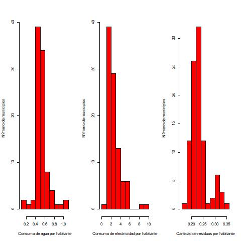

Figura 2. Distribuci?n de frecuencias de las tasas de consumo y generaci?n de residuos

En lo que respecta a las medidas mencionadas de posici?n, dispersi?n y forma, aparecen todas recogidas en la Tabla 2.

Tabla 2. Medidas estad?sticas descriptivas

|  | Media | P25 | Mediana | P75 | CVs | Coef.asimetr.a |
| --- | --- | --- | --- | --- | --- | --- |
| Tasa de consumo de agua | 0.53 | 0.46 | 0.51 | 0.56 | 0.26 | 1.22 |
| Tasa de consumo el?ctrico | 2.66 | 1.75 | 2.20 | 3.10 | 0.53 | 2.05 |
| Tasa de generaci?n de residuos | 0.23 | 0.21 | 0.23 | 0.24 | 0.16 | 1.39 |

Finalmente, como se menciona en la metodolog?a, utilizamos los diagramas de caja de la Figura 3 para identificar valores at?picos.

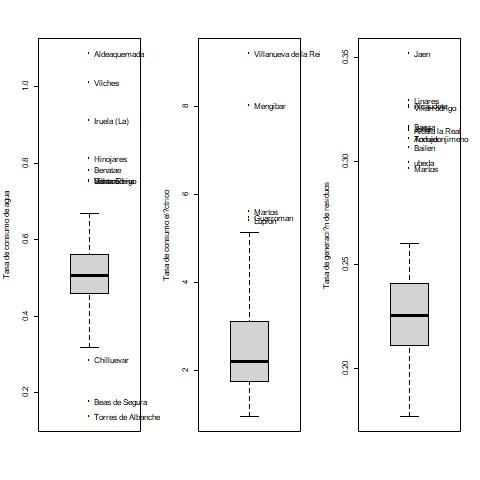

Figura 3. Diagramas de caja con valores at?picos en las tasas de consumo y generaci?n de residuos

## An?lisis

En lo que se refiere al destino de los residuos s?lidos urbanos, llama la atenci?n que s?lo la cuarta parte de los municipios utilizan plantas de compostaje para su tratamiento. Incluso sorprende la presencia de 11 municipios que utilizan vertederos no controlados para su almacenaje: Cazorla, Chilluevar, Hinojares, Huesa, Iruela (La), Larva, Peal de Becerro, Pozo Alcon, Quesada, Santo Tome, Santiago-Pontones.

## Conclusiones

La primera conclusi?n que queremos destacar es que algunos de los indicadores reflejan diferencias entre los municipios m?s poblados frente a los menos habitados: son municipios peque?os los que depositan los residuos en vertederos incontrolados y son municipios grandes los que resultan at?picos frente al resto por la cantidad promedio de residuos que generan.

No hemos logrado comprender la estructura que muestra la distribuci?n de la variable sobre el consumo promedio de agua. La presencia de municipios at?picos tanto por su elevado como por su reducido consumo promedio no nos ha permitido detectar ning?n patr?n que explique el por qu? de dicha variabilidad. Ser?a necesario un an?lisis m?s profundo y con un conocimiento m?s exhaustivo del tema para lograr arrojar luz sobre ello.